# R Notebook

Goal here is to compare observed and normalized flux from the UVP.

# Load libraries

```r
library(tidyverse)
library(readxl)
library(cowplot)
```

# Bring in all data.

## UVP

```r
unbinned_DepthSummary <- read_csv("dataOut/unbinned_DepthSummary.csv")
unbinned_EachSize <- read_csv("dataOut/unbinned_EachSize.csv")
binned_DepthSummary <- read_csv("dataOut/binned_DepthSummary.csv")
binned_EachSize <- read_csv("dataOut/binned_EachSize.csv")
```

## Flux

```r
fluxMS_distilled <- read_csv("dataOut/fluxMS_distilled")
```

# Redo Proctrap’s power law

# Power law flux model

```r
loglogCfluxmod <- glm(log10(C_flux_umol) ~ log10(Depth), data = fluxMS_distilled)
summary(loglogCfluxmod)
```

```
Call:
glm(formula = log10(C_flux_umol) ~ log10(Depth), data = fluxMS_distilled)

Deviance Residuals:
     Min        1Q    Median        3Q       Max
-0.42138  -0.20897  -0.01844   0.25313   0.39296

Coefficients:
             Estimate Std. Error t value Pr(>|t|)
(Intercept)    2.7122     0.5400   5.022 0.000389 ***
log10(Depth)  -0.4971     0.2408  -2.064 0.063386 .
---
Signif. codes:  0 ‘***’ 0.001 ‘**’ 0.01 ‘*’ 0.05 ‘.’ 0.1 ‘ ’ 1

(Dispersion parameter for gaussian family taken to be 0.07571012)

    Null deviance: 1.15546  on 12  degrees of freedom
Residual deviance: 0.83281  on 11  degrees of freedom
AIC: 7.1697

Number of Fisher Scoring iterations: 2
```

# Interpolate predicted flux profile

In non log space, added out of order on 06 December 2018

```r
CPred <- tibble(
  Depth = c(seq(from = 30, to = 150, by = 0.1),
            seq(from = 101, to = 1000, by = 1)
  )
)
CPred$C_flux_umol <- 10^predict(loglogCfluxmod, CPred)
```

## Flux profile for poster

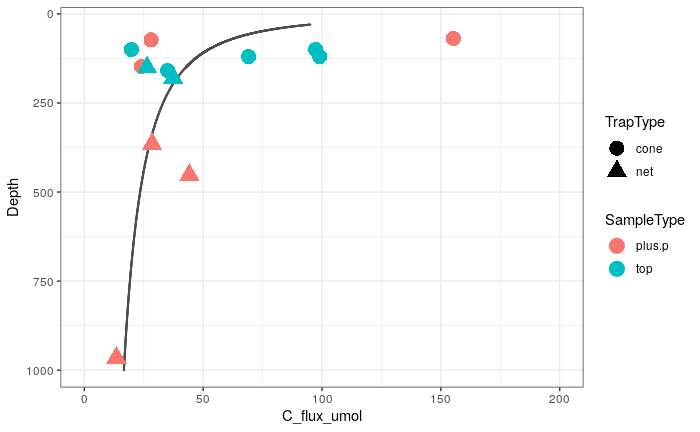

```r
FDP1 <- fluxMS_distilled %>% ggplot(aes(y = Depth, x = C_flux_umol)) +
    geom_point(data = CPred, aes(y = Depth, x = C_flux_umol), size = 0.1, colour = "gray30") +
  geom_point(aes(color = SampleType, shape = TrapType), size = 5) +
  scale_y_continuous(trans = "reverse") +
  scale_x_continuous(limits = c(0, 200)) +
  theme_bw()

FDP1
```

```r
#ggsave("figures/CFlux.svg", width = 7, height = 7)
```

# Estimated flux

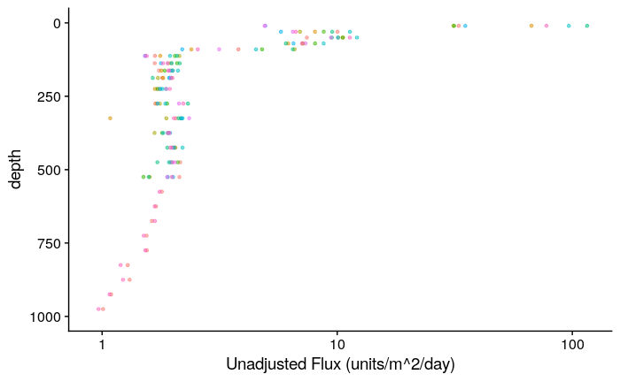

```r
plot_flux <- binned_DepthSummary %>% ggplot(aes(x = tot_flux, y = depth, colour = profile)) + geom_point(alpha = 0.5, size = 1) + scale_y_reverse(limits = c(1000,0)) + scale_x_log10() + guides(colour = FALSE) + labs(x = "Unadjusted Flux (units/m^2/day)")+
   theme_cowplot()
plot_flux
```

```r
pre_flux_compare <- binned_DepthSummary %>% group_by(depth) %>% summarize(tot_flux = mean(tot_flux)) %>%
  mutate(Depth = depth) %>% mutate(CFlux_trap_est = 10^predict(loglogCfluxmod, .))
```

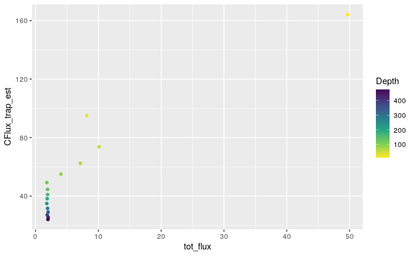

```r
pre_flux_compare %>% filter(Depth < 500) %>% ggplot(aes(x = tot_flux, y = CFlux_trap_est,  color = Depth)) + geom_point()  + scale_color_viridis_c(direction = -1) + scale_x_continuous() + scale_y_continuous()
```

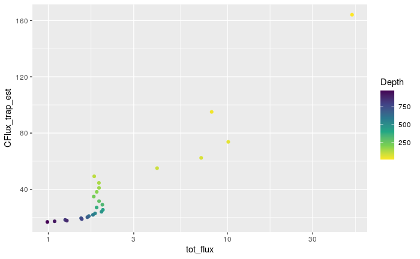

```r
pre_flux_compare %>% filter(Depth < 1000) %>% ggplot(aes(x = tot_flux, y = CFlux_trap_est,  color = Depth)) + geom_point()  + scale_color_viridis_c(direction = -1) + scale_x_log10() + scale_y_continuous()
```

These do not appear to be linearly related, at least for shallow depths. Total flux overestimates relative to trap flux.

Which do I believe more?

Lets say the trap flux. In that case, we could do a fit where total uvp flux is normalized to trap estimates, even in a non linear fashion.

So I’d do a regression where CFlux_trap ~ log10(tot_flux), and then I’d plot the predicted CFlux trap from the actual total flux. Thats my new power law.

```r
mod1 <- lm(CFlux_trap_est ~ log10(tot_flux), data = pre_flux_compare)
summary(mod1)
```

```
Call:
lm(formula = CFlux_trap_est ~ log10(tot_flux), data = pre_flux_compare)

Residuals:
    Min      1Q  Median      3Q     Max
-17.910  -4.677  -1.812   6.302  20.055

Coefficients:
                Estimate Std. Error t value Pr(>|t|)
(Intercept)        7.852      1.715    4.58 5.39e-05 ***
log10(tot_flux)   83.361      3.991   20.89  < 2e-16 ***
---
Signif. codes:  0 ‘***’ 0.001 ‘**’ 0.01 ‘*’ 0.05 ‘.’ 0.1 ‘ ’ 1

Residual standard error: 8.172 on 36 degrees of freedom
Multiple R-squared:  0.9238,    Adjusted R-squared:  0.9216
F-statistic: 436.2 on 1 and 36 DF,  p-value: < 2.2e-16
```

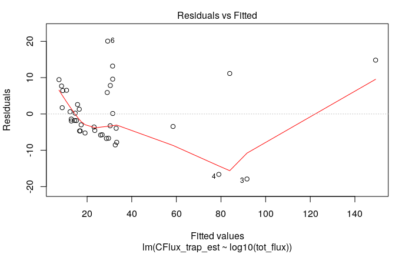

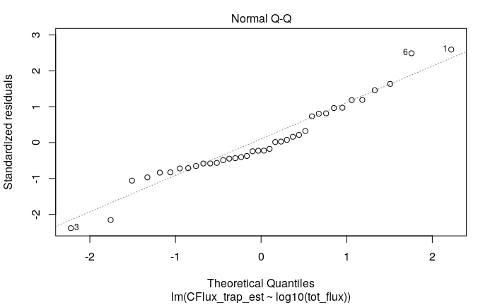

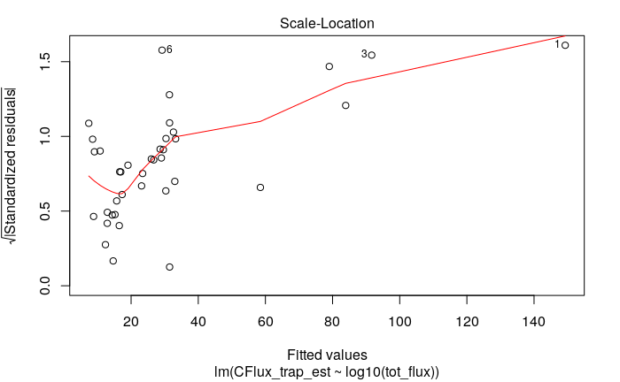

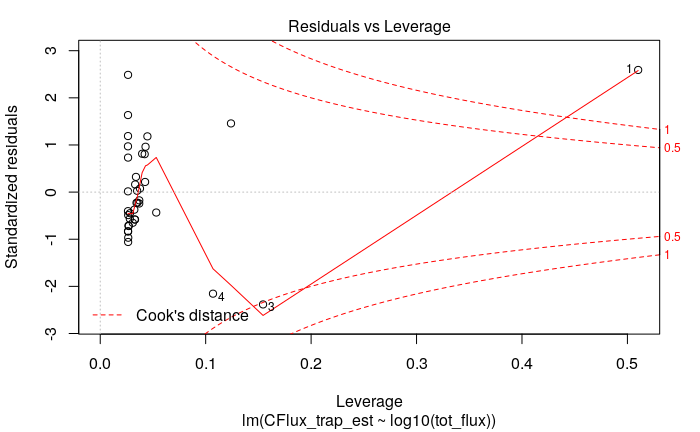

```r
plot(mod1)
```

```r
#rmse(mod1)
```

```r
flux_compare <- pre_flux_compare %>% mutate(tn_flux = predict(mod1, .))
```

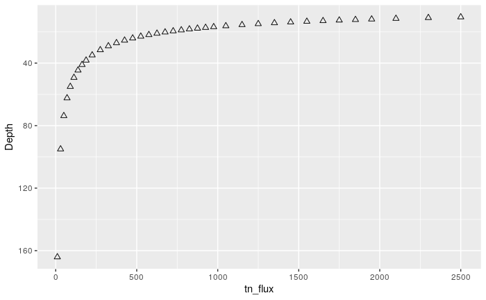

```r
flux_compare %>% ggplot(aes(y = Depth, x = tn_flux))  + scale_y_reverse() + geom_point(aes(x = Depth, y = CFlux_trap_est), shape = 2, size = 2)
```

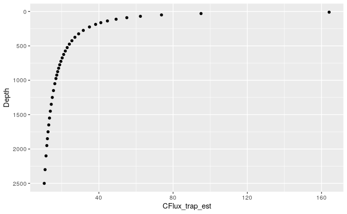

```r
flux_compare %>% ggplot(aes(y = Depth, x = CFlux_trap_est))  + scale_y_reverse() + geom_point()
```

```r
binned_DepthSummary_01 <- binned_DepthSummary %>% mutate(tn_flux = predict(mod1, .))
```

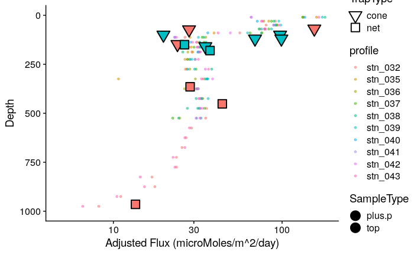

```r
plot_flux <- binned_DepthSummary_01 %>% rename(Depth = depth) %>% ggplot(aes(x = tn_flux, y = Depth)) + geom_point(alpha = 0.5, size = 1, aes(color = profile)) + scale_y_reverse(limits = c(1000,0)) + scale_x_log10()  + labs(x = "Adjusted Flux (microMoles/m^2/day)")+
   theme_cowplot() + geom_point(aes(y = Depth, x = C_flux_umol, fill = SampleType, shape = TrapType), colour = "black", stroke = 1, size = 5, data = fluxMS_distilled) +
  scale_shape_manual(values = c(25, 22))+
  scale_size_manual(values = c(3, 4))
plot_flux
```

This looks about an order of magnitude lowe rthan VanMooy 2002 or Harnett in that. Is it actually super low flux, or have I screwed up the math somewhere? Talk with Clara, and then Jacqui and Meg.

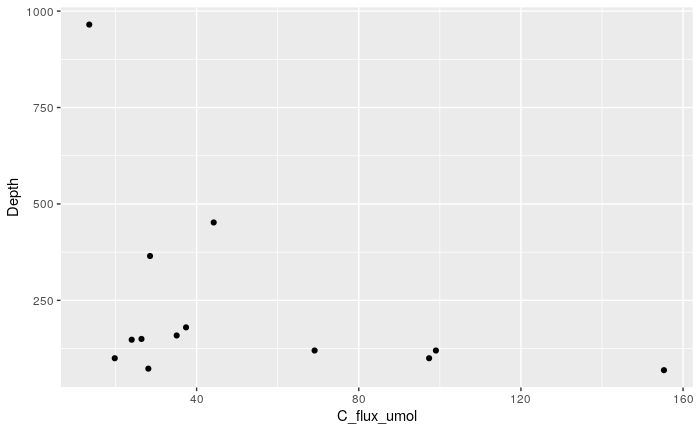

```r
ggplot() + geom_point(aes(y = Depth, x = C_flux_umol), data = fluxMS_distilled)
```

I think that maybe the alpha + gamma term is wrong, and thats why we have a non linear fit. We could try to minimize the R^2 value of the fit, while choosing C_f and alpha + gamma

```r
C_f_test <- 1
ag_test <- 1.7 + 1.7 - 1

fit_flux_es <- function( C_f, ag, ES1 = binned_EachSize){
ES2 <- binned_EachSize %>% mutate(flux2 = C_f * nparticles * lb ^ ag)
ES2
}

#ES2 <- fit_flux_es(C_f_test, ag_test) %>% select(profile:depth, flux, flux2) # flux == flux2

 fit_flux_ds <- function(C_f, ag, ES2, DS1 = binned_DepthSummary_01){
  DS2 <- ES2 %>%
    group_by(profile, time, depth) %>%
    summarize(tot_flux2 = sum(flux2))

  DS2 <- left_join(DS1, DS2, by = c("profile", "time", "depth"))
}

#DS2 <- fit_flux_ds(C_f_test, ag_test, ES2)

#DS2 %>% select(profile:depth, tot_flux, tot_flux2) # flux == flux2

fit_flux <- function(C_f, ag, ES1, DS1){
  ES2 <- fit_flux_es(C_f, ag, ES1)
  DS2 <- fit_flux_ds(C_f, ag, ES2, DS1)
  return(list(ES = ES2, DS = DS2))
}

FFTest <- fit_flux(C_f_test, ag_test, binned_EachSize, binned_DepthSummary_01)

# https://stackoverflow.com/questions/43123462/how-to-obtain-rmse-out-of-lm-result
RMSE <- function(mod){
  RSS <- c(crossprod(mod$residuals))
  MSE = RSS/ length(mod$residuals)
  RMSE = sqrt(MSE)
}

# Close, but too much weight on larger values
flux_check <- function(DS){
  #diff = log10(DS$tn_flux) - log10(DS$tot_flux2)
  diff = log(DS$tn_flux) - log(DS$tot_flux2)
  squares = diff ^2
  rss = sum(squares)
  mse = rss/length(rss)
  rmse = sqrt(mse)
  rmse
}

#flux_check(FFTest$DS)

fit_check_flux <- function(C_f, ag, ES1, DS1){
  FF <- fit_flux(C_f, ag, ES1, DS1)
  FC <- flux_check(FF$DS)
  FC
}

fit_check_flux(C_f_test, ag_test, binned_EachSize, binned_DepthSummary_01)
```

```
[1] 65.0345
```

```r
fc_wrap <- function(x){
  C_f <- x[1]
  ag <- x[2]
  FC <- fit_check_flux(C_f, ag, binned_EachSize, binned_DepthSummary_01)
  FC
}
```

I’m getting two f values for my tests. 248 and 306. Not sure what gives, but not going to dig right now. 02 Feb 2019

Now iterate over all reasonable C_f and ag

```r
opt <- optim(c(C_f_test, ag_test), fc_wrap)
opt
```

```
$par
[1]  0.03543784 -2.11550560

$value
[1] 4.368711

$counts
function gradient
     429       NA

$convergence
[1] 0

$message
NULL
```

```r
fit_alpha = (opt$par[2] +1)/2
fit_alpha
```

```
[1] -0.5577528
```

```r
fit_gamma = fit_alpha - 1
fit_gamma
```

```
[1] -1.557753
```

So in this scenario, big particles sink slower than small particles.

```r
#opt <- optim(c(C_f_test, ag_test), fc_wrap, method = "L-BFGS-B", lower = c(0, 0), upper = c(Inf, 10))
#opt
```

```r
OptFlux <- fit_flux(opt$par[1], opt$par[2], binned_EachSize, binned_DepthSummary_01)
binned_EachSize_02 <- OptFlux$ES
binned_DepthSummary_02 <- OptFlux$DS
```

This isn’t working. Things don’t actually fit well with this optimum fit.

```r
flux_check(binned_DepthSummary_02)
```

```
[1] 4.368711
```

Changing the C_f parameter isn’t improving the vit

Debugging

```r
mod2 <- lm(tn_flux~tot_flux2, data = binned_DepthSummary_02)
summary(mod2)
```

```
Call:
lm(formula = tn_flux ~ tot_flux2, data = binned_DepthSummary_02)

Residuals:
    Min      1Q  Median      3Q     Max
-73.660  -9.855  -5.491  -0.446  71.075

Coefficients:
            Estimate Std. Error t value Pr(>|t|)
(Intercept) 32.41137    1.70957   18.96   <2e-16 ***
tot_flux2    0.17840    0.01076   16.58   <2e-16 ***
---
Signif. codes:  0 ‘***’ 0.001 ‘**’ 0.01 ‘*’ 0.05 ‘.’ 0.1 ‘ ’ 1

Residual standard error: 20.54 on 171 degrees of freedom
Multiple R-squared:  0.6166,    Adjusted R-squared:  0.6144
F-statistic:   275 on 1 and 171 DF,  p-value: < 2.2e-16
```

Oh. I don’t want to do LM. It always rescales so C_f doesn’t have any effect. I want to calculate RMSE by hand. EG. Get difference between each trap and predicted flux, square them, add them, devide by length, take the square root, or even just square and add.

# Plot check

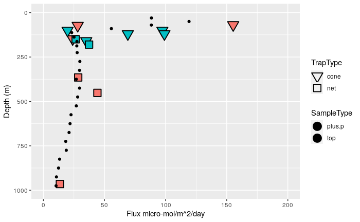

```r
binned_DepthSummary_02 %>% group_by(depth) %>% summarize(tot_flux2 = mean(tot_flux2)) %>% ggplot(aes(y = depth))  + scale_y_reverse(limits = c(1000, 0)) + scale_x_continuous(limits = c(0, 200)) +
  geom_point(aes(y = Depth, x = C_flux_umol, fill = SampleType, shape = TrapType), colour = "black", stroke = 1, size = 5, data = fluxMS_distilled) +
  geom_point(aes(x = tot_flux2)) +
scale_shape_manual(values = c(25, 22))+
  scale_size_manual(values = c(3, 4)) +
  ylab("Depth (m)") + xlab("Flux micro-mol/m^2/day")
```

```r
NA
```

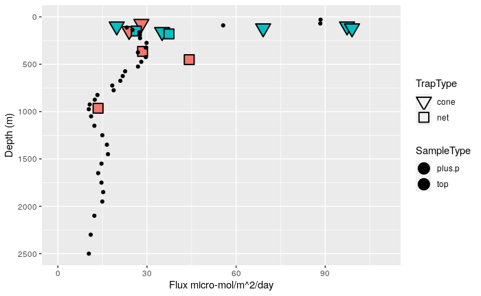

```r
binned_DepthSummary_02 %>% group_by(depth) %>% summarize(tot_flux2 = mean(tot_flux2)) %>% ggplot(aes(y = depth))  + scale_y_reverse(limits = c(2500, 0)) + scale_x_continuous(limits = c(0, 110)) +
  geom_point(aes(y = Depth, x = C_flux_umol, fill = SampleType, shape = TrapType), colour = "black", stroke = 1, size = 5, data = fluxMS_distilled) +
  geom_point(aes(x = tot_flux2)) +
scale_shape_manual(values = c(25, 22))+
  scale_size_manual(values = c(3, 4)) +
  ylab("Depth (m)") + xlab("Flux micro-mol/m^2/day")
```

```r
NA
```

binned_DepthSummary_02

```r
write_csv(binned_DepthSummary_02, "dataOut/binned_DepthSummary_02.csv")
```

# 02 April 2019

# Fitting directly to traps

Alternative approach. What if, instead of fitting a power law to flux and “up sampling” I instead down sample the UVP data to match the flux. I could do this, for instance by coursely binning and then just taking the nearist bin.

```r
trapDepths <- fluxMS_distilled  %>% pull(Depth) %>% unique
trapDepths
```

```
 [1]  69  73 148 365 452 965 100 120 150 159 180
```

```r
uvpDepths <- binned_EachSize %>% filter(profile == "stn_043") %>% pull(depth) %>% unique
uvpDepths
```

```
 [1]   10.0   30.0   50.0   70.0   90.0  112.5  137.5  162.5  187.5  225.0  275.0  325.0  375.0  425.0  475.0  525.0  575.0  625.0  675.0  725.0  775.0  825.0  875.0  925.0  975.0 1050.0 1150.0 1250.0 1350.0 1450.0 1550.0
[32] 1650.0 1750.0 1850.0 1950.0 2100.0 2300.0 2500.0
```

```r
nearist <- function(dep, dvec = uvpDepths){dvec[which.min(abs(dvec - dep))]}
nearist(69)
```

```
[1] 70
```

```r
fluxMS_distilled %>% mutate(NearistUVPDepth = map_dbl(Depth, nearist))
```

| Class | Depth | TrapID | TrapType | SampleType | C_flux | C_flux_umol | NearistUVPDepth |
| --- | --- | --- | --- | --- | --- | --- | --- |
| Organic | 69 | 4-22 | cone | plus.p | 1.8634620 | 155.28850 | 70.0 |
| Organic | 73 | 1-12 | cone | plus.p | 0.3370870 | 28.09058 | 70.0 |
| Organic | 148 | 1-12 | cone | plus.p | 0.2877667 | 23.98056 | 137.5 |
| Organic | 365 | 3-21 | net | plus.p | 0.3420703 | 28.50585 | 375.0 |
| Organic | 452 | 3-21 | net | plus.p | 0.5305802 | 44.21501 | 475.0 |
| Organic | 965 | 4-13 | net | plus.p | 0.1622163 | 13.51802 | 975.0 |
| Organic | 100 | 2-14 | cone | top | 0.2376192 | 19.80160 | 90.0 |
| Organic | 100 | 2-17 | cone | top | 1.1682353 | 97.35294 | 90.0 |
| Organic | 120 | 3-15 | cone | top | 0.8292443 | 69.10369 | 112.5 |
| Organic | 120 | 3-18 | cone | top | 1.1883803 | 99.03169 | 112.5 |

[output cut: 3 more lines]

```r
left_join(
  fluxMS_distilled %>% mutate(NearistUVPDepth = map_dbl(Depth, nearist)),
  binned_DepthSummary_02 %>% filter(profile == "stn_043") %>% select(depth, tot_flux2),
  by = c("NearistUVPDepth" = "depth")
)
```

| Class | Depth | TrapID | TrapType | SampleType | C_flux | C_flux_umol | NearistUVPDepth | tot_flux2 |
| --- | --- | --- | --- | --- | --- | --- | --- | --- |
| Organic | 69 | 4-22 | cone | plus.p | 1.8634620 | 155.28850 | 70.0 | 90.430809 |
| Organic | 73 | 1-12 | cone | plus.p | 0.3370870 | 28.09058 | 70.0 | 90.430809 |
| Organic | 148 | 1-12 | cone | plus.p | 0.2877667 | 23.98056 | 137.5 | 25.780837 |
| Organic | 365 | 3-21 | net | plus.p | 0.3420703 | 28.50585 | 375.0 | 28.887516 |
| Organic | 452 | 3-21 | net | plus.p | 0.5305802 | 44.21501 | 475.0 | 28.297653 |
| Organic | 965 | 4-13 | net | plus.p | 0.1622163 | 13.51802 | 975.0 | 9.993645 |
| Organic | 100 | 2-14 | cone | top | 0.2376192 | 19.80160 | 90.0 | 33.326443 |
| Organic | 100 | 2-17 | cone | top | 1.1682353 | 97.35294 | 90.0 | 33.326443 |
| Organic | 120 | 3-15 | cone | top | 0.8292443 | 69.10369 | 112.5 | 21.577036 |
| Organic | 120 | 3-18 | cone | top | 1.1883803 | 99.03169 | 112.5 | 21.577036 |

[output cut: 3 more lines]

BOOKMARK 02 April 2020

```r
fluxMS_distilled_connect <- fluxMS_distilled %>% mutate(NearistUVPDepth = map_dbl(Depth, nearist))

flux_check_vs_traps <- function(DS, FLX = fluxMS_distilled_connect){

  thing <- left_join(
    FLX,
    DS %>% filter(profile == "stn_043") %>% select(depth, tot_flux2),
    by = c("NearistUVPDepth" = "depth")
                     )

  #diff = log10(DS$tn_flux) - log10(DS$tot_flux2)
  diff = log(thing$C_flux_umol) - log(thing$tot_flux2)
  squares = diff ^2
  rss = sum(squares)
  mse = rss/length(rss)
  rmse = sqrt(mse)
  rmse
}

flux_check_vs_traps(binned_DepthSummary_02, fluxMS_distilled_connect)
```

```
[1] 2.674664
```

```r
fit_check_flux_vstraps <- function(C_f, ag, ES1, DS1, FLX = fluxMS_distilled_connect){
  FF <- fit_flux(C_f, ag, ES1, DS1)
  FC <- flux_check_vs_traps(FF$DS, FLX)
  FC
}

fit_check_flux_vstraps(C_f_test, ag_test, binned_EachSize, binned_DepthSummary, fluxMS_distilled_connect)
```

```
[1] 19.66565
```

```r
fc_wrap_vstraps <- function(x){
  C_f <- x[1]
  ag <- x[2]
  FC <- fit_check_flux_vstraps(C_f, ag, binned_EachSize, binned_DepthSummary)
  FC
}

opt_vstraps <- optim(c(C_f_test, ag_test), fc_wrap_vstraps)
opt_vstraps
```

```
$par
[1]  0.05184768 -2.07263336

$value
[1] 2.46458

$counts
function gradient
     501       NA

$convergence
[1] 1

$message
NULL
```

Seriously. Now its negative?

Post mortem

```r
negAlpha <- fit_flux(opt_vstraps$par[1], opt_vstraps$par[2], binned_EachSize, binned_DepthSummary)
```

```r
negAlpha_ES <- negAlpha$ES
negAlpha_DS <- negAlpha$DS
```

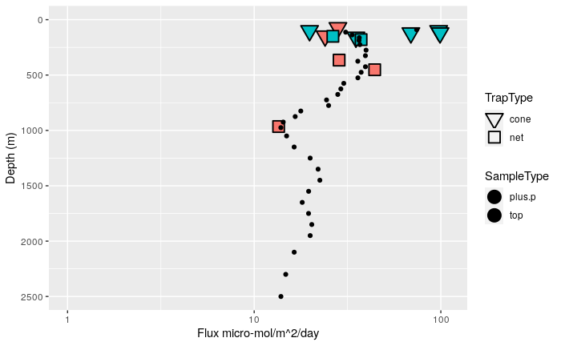

```r
negAlpha_DS %>% group_by(depth) %>% summarize(tot_flux2 = mean(tot_flux2)) %>% ggplot(aes(y = depth))  + scale_y_reverse(limits = c(2500, 0)) + scale_x_log10(limits = c(1, 110)) +
  geom_point(aes(y = Depth, x = C_flux_umol, fill = SampleType, shape = TrapType), colour = "black", stroke = 1, size = 5, data = fluxMS_distilled) +
  geom_point(aes(x = tot_flux2)) +
scale_shape_manual(values = c(25, 22))+
  scale_size_manual(values = c(3, 4)) +
  ylab("Depth (m)") + xlab("Flux micro-mol/m^2/day")
```

# If we don’t optimize ag

Use values from Alldredge and Gotschalk gamma = 0.26 alpha = 0.52

```r
alldredge_alpha = 0.52 # alldredge
alldredge_gamma = 0.26 # alldrege and gotschalk
alldredge_ag = alldredge_alpha + alldredge_gamma # Alldredge
fc_wrap_CfOnly <- function(x){
  C_f <- x[1]
  FC <- fit_check_flux(C_f, alldredge_ag, binned_EachSize, binned_DepthSummary_01)
  FC
}

opt_alldredge <- optim(c(C_f_test), fc_wrap_CfOnly, method = "Brent", lower = 0, upper = 1000)

opt_alldredge$par[2] <- alldredge_ag
opt_alldredge
```

```
$par
[1] 13.03289  0.78000

$value
[1] 5.427224

$counts
function gradient
      NA       NA

$convergence
[1] 0

$message
NULL
```

Now that I’m running this. Alpha + gamma looks a lot more reasonalbe as 0.26. I mean, here its only 0.78.

More optomistic post mortem

```r
OptFlux_ald <- fit_flux(opt$par[1], opt$par[2], binned_EachSize, binned_DepthSummary_01)
binned_EachSize_ald <- OptFlux_ald$ES
binned_DepthSummary_ald <- OptFlux_ald$DS
```

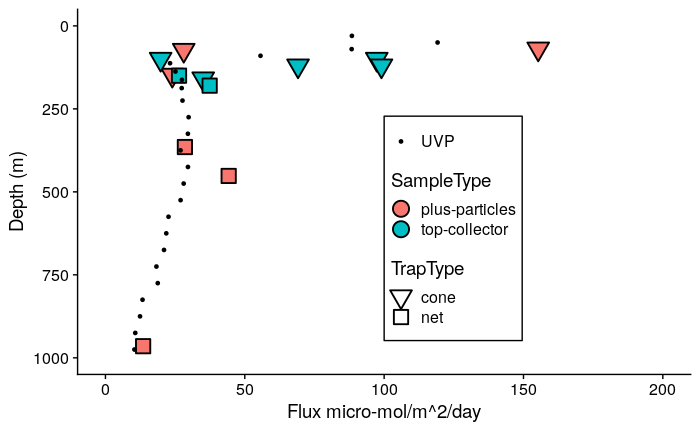

```r
binned_DepthSummary_ald_toPlot <- binned_DepthSummary_ald %>% group_by(depth) %>% summarize(tot_flux2 = mean(tot_flux2))

fluxMS_distilled_toPlot <- fluxMS_distilled %>%
  mutate(SampleType = recode(SampleType, `plus.p` = "plus-particles", top = "top-collector"))

binned_DepthSummary_ald_toPlot %>%
  ggplot(aes(y = depth))  + scale_y_reverse(limits = c(1000, 0)) +
  scale_x_continuous(limits = c(0, 200)) +
  geom_point(aes(y = Depth, x = C_flux_umol, fill = SampleType, shape = TrapType),
             colour = "black", stroke = 1, size = 5, data = fluxMS_distilled_toPlot) +
  geom_point(aes(x = tot_flux2, size = "UVP")) +
scale_shape_manual(values = c(25, 22))+
  scale_size_manual(values = 1, name = "") +
  ylab("Depth (m)") + xlab("Flux micro-mol/m^2/day") +
  guides(fill = guide_legend(override.aes = list(shape = 21))) +
  theme_cowplot() +
  theme(
        legend.position = c(0.5, 0.4),
        legend.box.background = element_rect(color = "black", size = 0.5),
        legend.margin = margin(-10, 5, 10, 5)
  )
```

```r
#ggsave("figures/Cf_fitted_flux_wTraps.svg")
```

```r
write_csv(binned_DepthSummary_ald, "dataOut/binned_DepthSummary_ald.csv")
write_csv(binned_EachSize_ald, "dataOut/binned_EachSize_ald.csv")
```